# Concentration of Returns Comparison

Jonathan Rossouw

4 December 2021

### Abstract

This document contains an anaylsis of the correlation of returns for the JSE Top 40. The analysis make use of PCA and rolling constituent correlation techniques. High volatility periods are additionally considered.

# Introduction

This document contains an anaylsis of the correlation of returns for the JSE Top 40. The analysis make use of PCA and rolling constituent correlation techniques. High volatility periods are additionally considered.

# 1 Normal Times

## 1.1 PCA

Following the PCA scree plot, the first principle component explains 25.9% of variation in the data, while the second explains 8.2%. The rest of the components gradually explain less but not insignificant amounts. This means that the data is not concentrated in a few directions. From the variables plot, there seems to be two distinct groupings. The groups are close to orthogonal which could indicate the possibility of potential diversification. Dim 1 consists of financial sector stocks primarily, while Dim 2 consists of resource stocks.

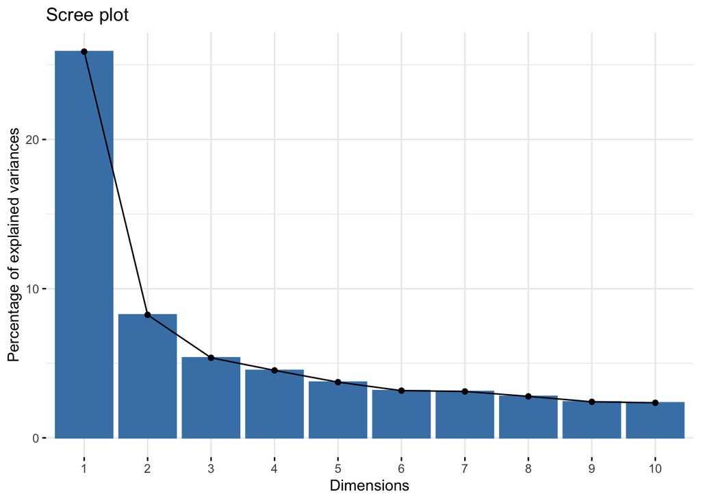

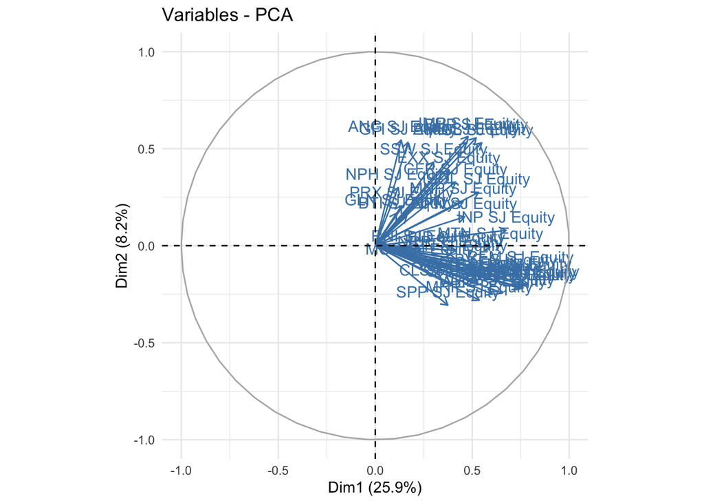

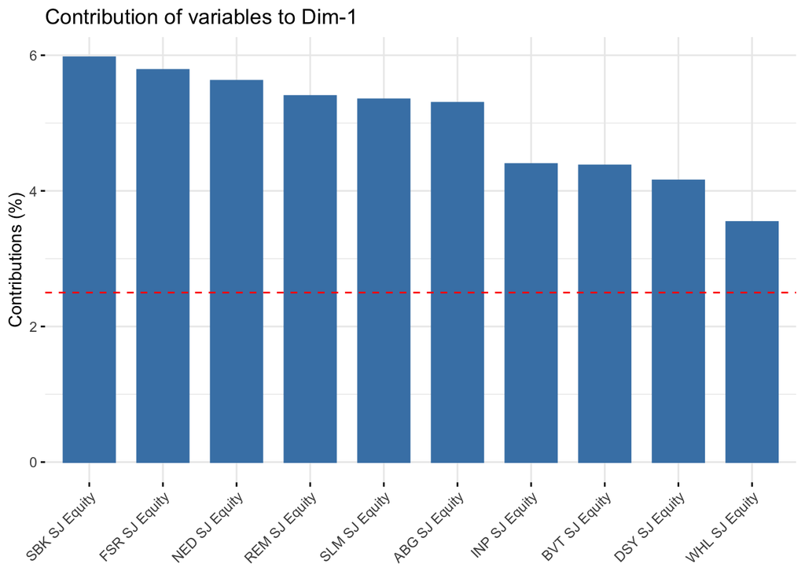

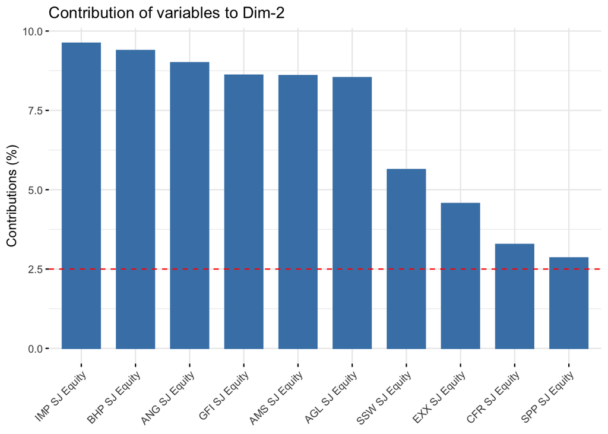

## 1.2 RCC

From the rolling constituent correlation plot, the market has alternating periods of high co-movement and low co-movement. Particularly in the early 2010s.

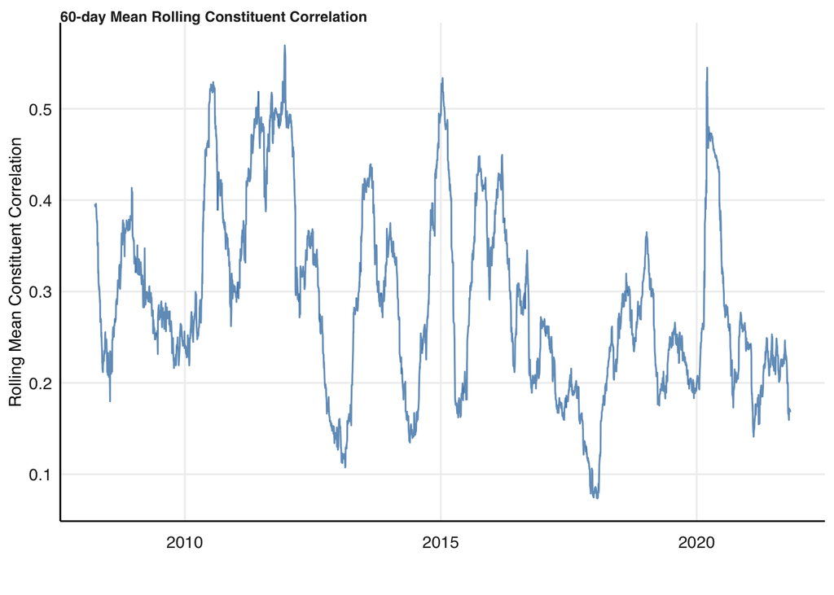

# 2 High Volatility Periods

There are 33 months of volatility greater than 80% of months.

## 2.1 PCA

During these periods, there is a greater concentration of co-movements. The first principal component accounts for 31.9% of variation. A similar pattern emerges to the normal times. Financials make up most of the Dim 1 while Resources make up most of Dim 2.

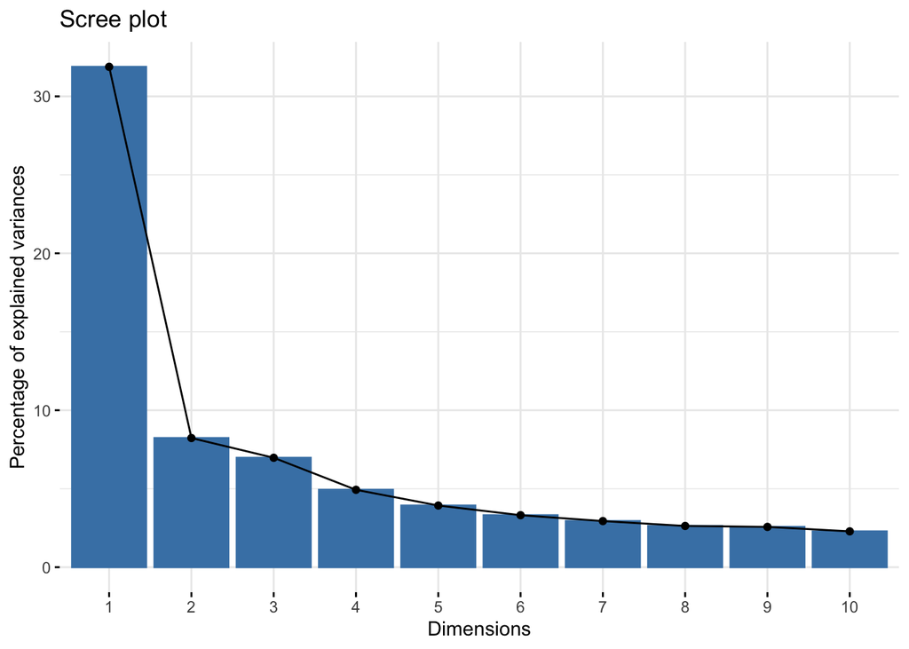

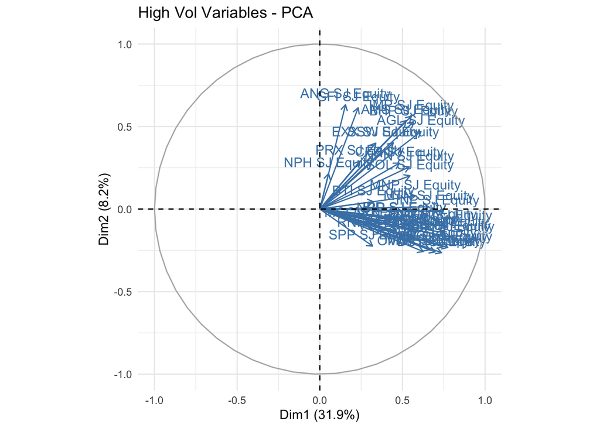

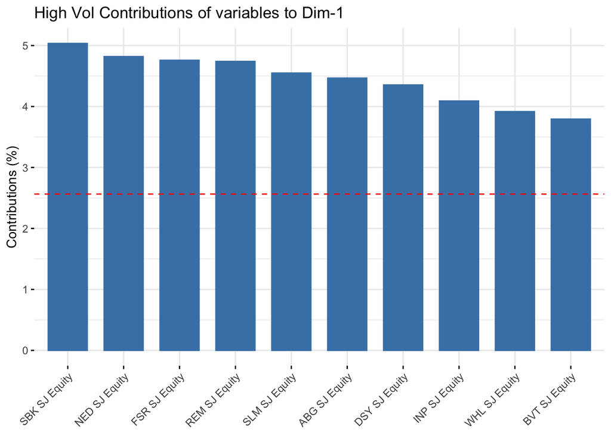

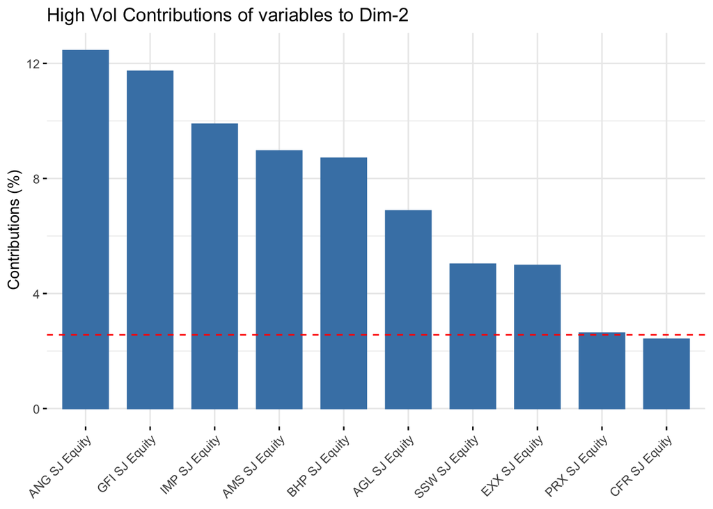

## 2.2 RCC

The RCC for the high vol periods does not express higher co-movement that the RCC for normal times. However, the co-movement is never as low as during the lowest normal times.

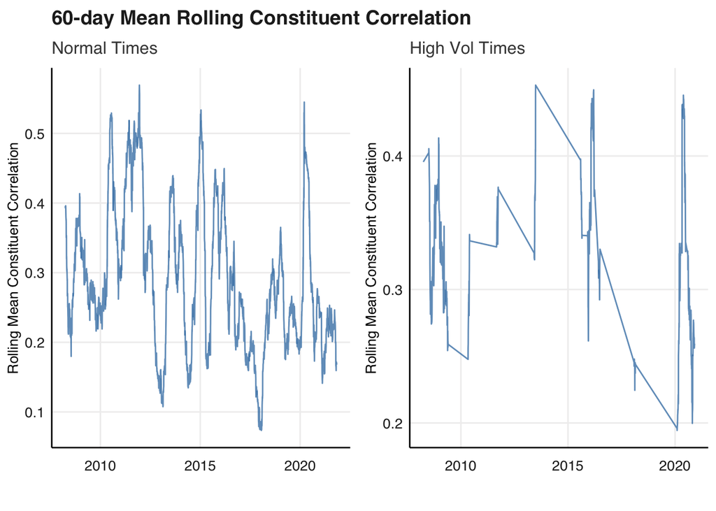